# Project: Investigation of No-show appointments in Brazil

Table of Contents:

Introduction

Data Wrangling

Exploratory Data Analysis

Conclusion

# Introduction

This dataset contains information about patients in Brazil and whether or not they showed up for their scheduled doctors appointments.  
The aim of the study is to find possible links between patient data and whether it increases the liklihood of a no-show.

To do that, I will look to answer the following questions:

- Most common amount of days between appt and schd for no shows?
- Most common age for no shows?
- Does disability/handicap create more no shows?
- Which gender no shows more often?
- Does having a scholarship make you no show less?
- Most common neighbourhood for no shows?
- Does receiving the SMS help?

```python
import pandas as pd
import numpy as np

df = pd.read_csv('noshowappointments.csv')
df.head()
```

|  | PatientId | AppointmentID | Gender | ScheduledDay | AppointmentDay | Age | Neighbourhood | Scholarship | Hipertension | Diabetes | Alcoholism | Handcap | SMS_received | No-show |
| --- | --- | --- | --- | --- | --- | --- | --- | --- | --- | --- | --- | --- | --- | --- |
| 0 | 2.987250e+13 | 5642903 | F | 2016-04-29T18:38:08Z | 2016-04-29T00:00:00Z | 62 | JARDIM DA PENHA | 0 | 1 | 0 | 0 | 0 | 0 | No |
| 1 | 5.589978e+14 | 5642503 | M | 2016-04-29T16:08:27Z | 2016-04-29T00:00:00Z | 56 | JARDIM DA PENHA | 0 | 0 | 0 | 0 | 0 | 0 | No |
| 2 | 4.262962e+12 | 5642549 | F | 2016-04-29T16:19:04Z | 2016-04-29T00:00:00Z | 62 | MATA DA PRAIA | 0 | 0 | 0 | 0 | 0 | 0 | No |
| 3 | 8.679512e+11 | 5642828 | F | 2016-04-29T17:29:31Z | 2016-04-29T00:00:00Z | 8 | PONTAL DE CAMBURI | 0 | 0 | 0 | 0 | 0 | 0 | No |
| 4 | 8.841186e+12 | 5642494 | F | 2016-04-29T16:07:23Z | 2016-04-29T00:00:00Z | 56 | JARDIM DA PENHA | 0 | 1 | 1 | 0 | 0 | 0 | No |

```python
df.shape
```

```
(110527, 14)
```

```python
df.dtypes
```

```
PatientId         float64
AppointmentID       int64
Gender             object
ScheduledDay       object
AppointmentDay     object
Age                 int64
Neighbourhood      object
Scholarship         int64
Hipertension        int64
Diabetes            int64
Alcoholism          int64
Handcap             int64
SMS_received        int64
No-show            object
dtype: object
```

```python
df.info()

# No missing data from any row and no null entries
```

```
<class 'pandas.core.frame.DataFrame'>
RangeIndex: 110527 entries, 0 to 110526
Data columns (total 14 columns):
PatientId         110527 non-null float64
AppointmentID     110527 non-null int64
Gender            110527 non-null object
ScheduledDay      110527 non-null object
AppointmentDay    110527 non-null object
Age               110527 non-null int64
Neighbourhood     110527 non-null object
Scholarship       110527 non-null int64
Hipertension      110527 non-null int64
Diabetes          110527 non-null int64
Alcoholism        110527 non-null int64
Handcap           110527 non-null int64
SMS_received      110527 non-null int64
No-show           110527 non-null object
dtypes: float64(1), int64(8), object(5)
memory usage: 11.8+ MB
```

```python
# Change column names to be consistent
# lower case letters and _

df.columns = [
    'patientID', 'appointmentID', 'gender', 'scheduled_day',
    'appointment_day', 'age', 'neighbourhood', 'scholarship',
    'hypertension', 'diabetes', 'alcoholism', 'handicap', 'SMS_received',
    'no_show'
    ]
df.head()
```

|  | patientID | appointmentID | gender | scheduled_day | appointment_day | age | neighbourhood | scholarship | hypertension | diabetes | alcoholism | handicap | SMS_received | no_show |
| --- | --- | --- | --- | --- | --- | --- | --- | --- | --- | --- | --- | --- | --- | --- |
| 0 | 2.987250e+13 | 5642903 | F | 2016-04-29T18:38:08Z | 2016-04-29T00:00:00Z | 62 | JARDIM DA PENHA | 0 | 1 | 0 | 0 | 0 | 0 | No |
| 1 | 5.589978e+14 | 5642503 | M | 2016-04-29T16:08:27Z | 2016-04-29T00:00:00Z | 56 | JARDIM DA PENHA | 0 | 0 | 0 | 0 | 0 | 0 | No |
| 2 | 4.262962e+12 | 5642549 | F | 2016-04-29T16:19:04Z | 2016-04-29T00:00:00Z | 62 | MATA DA PRAIA | 0 | 0 | 0 | 0 | 0 | 0 | No |
| 3 | 8.679512e+11 | 5642828 | F | 2016-04-29T17:29:31Z | 2016-04-29T00:00:00Z | 8 | PONTAL DE CAMBURI | 0 | 0 | 0 | 0 | 0 | 0 | No |
| 4 | 8.841186e+12 | 5642494 | F | 2016-04-29T16:07:23Z | 2016-04-29T00:00:00Z | 56 | JARDIM DA PENHA | 0 | 1 | 1 | 0 | 0 | 0 | No |

```python
df.gender.value_counts()

# Straight forward, no cleaning needed. Note twice as many females as males
```

```
F    71840
M    38687
Name: gender, dtype: int64
```

# Data Wrangling

```python
# Make from scholarship to alcoholism booleans

df.iloc[:, 7:11] = df.iloc[:, 7:11].astype(bool)
```

```python
df.head()
```

|  | patientID | appointmentID | gender | scheduled_day | appointment_day | age | neighbourhood | scholarship | hypertension | diabetes | alcoholism | handicap | SMS_received | no_show |
| --- | --- | --- | --- | --- | --- | --- | --- | --- | --- | --- | --- | --- | --- | --- |
| 0 | 2.987250e+13 | 5642903 | F | 2016-04-29T18:38:08Z | 2016-04-29T00:00:00Z | 62 | JARDIM DA PENHA | False | True | False | False | 0 | 0 | No |
| 1 | 5.589978e+14 | 5642503 | M | 2016-04-29T16:08:27Z | 2016-04-29T00:00:00Z | 56 | JARDIM DA PENHA | False | False | False | False | 0 | 0 | No |
| 2 | 4.262962e+12 | 5642549 | F | 2016-04-29T16:19:04Z | 2016-04-29T00:00:00Z | 62 | MATA DA PRAIA | False | False | False | False | 0 | 0 | No |
| 3 | 8.679512e+11 | 5642828 | F | 2016-04-29T17:29:31Z | 2016-04-29T00:00:00Z | 8 | PONTAL DE CAMBURI | False | False | False | False | 0 | 0 | No |
| 4 | 8.841186e+12 | 5642494 | F | 2016-04-29T16:07:23Z | 2016-04-29T00:00:00Z | 56 | JARDIM DA PENHA | False | True | True | False | 0 | 0 | No |

```python
# Make SMS_received a boolean

df.iloc[:, 12:13] = df.iloc[:, 12:13].astype(bool)
df.head()
```

|  | patientID | appointmentID | gender | scheduled_day | appointment_day | age | neighbourhood | scholarship | hypertension | diabetes | alcoholism | handicap | SMS_received | no_show |
| --- | --- | --- | --- | --- | --- | --- | --- | --- | --- | --- | --- | --- | --- | --- |
| 0 | 2.987250e+13 | 5642903 | F | 2016-04-29T18:38:08Z | 2016-04-29T00:00:00Z | 62 | JARDIM DA PENHA | False | True | False | False | 0 | False | No |
| 1 | 5.589978e+14 | 5642503 | M | 2016-04-29T16:08:27Z | 2016-04-29T00:00:00Z | 56 | JARDIM DA PENHA | False | False | False | False | 0 | False | No |
| 2 | 4.262962e+12 | 5642549 | F | 2016-04-29T16:19:04Z | 2016-04-29T00:00:00Z | 62 | MATA DA PRAIA | False | False | False | False | 0 | False | No |
| 3 | 8.679512e+11 | 5642828 | F | 2016-04-29T17:29:31Z | 2016-04-29T00:00:00Z | 8 | PONTAL DE CAMBURI | False | False | False | False | 0 | False | No |
| 4 | 8.841186e+12 | 5642494 | F | 2016-04-29T16:07:23Z | 2016-04-29T00:00:00Z | 56 | JARDIM DA PENHA | False | True | True | False | 0 | False | No |

```python
df.no_show.value_counts()
```

```
No     88208
Yes    22319
Name: no_show, dtype: int64
```

```python
df.to_csv('noshowscleanedv1.csv', index=False)
```

```python
import pandas as pd
import numpy as np

df = pd.read_csv('noshowscleanedv1.csv')
df.head()
```

|  | patientID | appointmentID | gender | scheduled_day | appointment_day | age | neighbourhood | scholarship | hypertension | diabetes | alcoholism | handicap | SMS_received | no_show |
| --- | --- | --- | --- | --- | --- | --- | --- | --- | --- | --- | --- | --- | --- | --- |
| 0 | 2.987250e+13 | 5642903 | F | 2016-04-29T18:38:08Z | 2016-04-29T00:00:00Z | 62 | JARDIM DA PENHA | False | True | False | False | 0 | False | No |
| 1 | 5.589978e+14 | 5642503 | M | 2016-04-29T16:08:27Z | 2016-04-29T00:00:00Z | 56 | JARDIM DA PENHA | False | False | False | False | 0 | False | No |
| 2 | 4.262962e+12 | 5642549 | F | 2016-04-29T16:19:04Z | 2016-04-29T00:00:00Z | 62 | MATA DA PRAIA | False | False | False | False | 0 | False | No |
| 3 | 8.679512e+11 | 5642828 | F | 2016-04-29T17:29:31Z | 2016-04-29T00:00:00Z | 8 | PONTAL DE CAMBURI | False | False | False | False | 0 | False | No |
| 4 | 8.841186e+12 | 5642494 | F | 2016-04-29T16:07:23Z | 2016-04-29T00:00:00Z | 56 | JARDIM DA PENHA | False | True | True | False | 0 | False | No |

```python
# Replace Yes and No in no_show column to true and false, to make it more intuitive

df =df.replace({'no_show': {'Yes': True, 'No': False}})
df.head()

# help: https://stackoverflow.com/questions/43897296/pandas-converting-yes-no-to-true-false-failing
```

|  | patientID | appointmentID | gender | scheduled_day | appointment_day | age | neighbourhood | scholarship | hypertension | diabetes | alcoholism | handicap | SMS_received | no_show |
| --- | --- | --- | --- | --- | --- | --- | --- | --- | --- | --- | --- | --- | --- | --- |
| 0 | 2.987250e+13 | 5642903 | F | 2016-04-29T18:38:08Z | 2016-04-29T00:00:00Z | 62 | JARDIM DA PENHA | False | True | False | False | 0 | False | False |
| 1 | 5.589978e+14 | 5642503 | M | 2016-04-29T16:08:27Z | 2016-04-29T00:00:00Z | 56 | JARDIM DA PENHA | False | False | False | False | 0 | False | False |
| 2 | 4.262962e+12 | 5642549 | F | 2016-04-29T16:19:04Z | 2016-04-29T00:00:00Z | 62 | MATA DA PRAIA | False | False | False | False | 0 | False | False |
| 3 | 8.679512e+11 | 5642828 | F | 2016-04-29T17:29:31Z | 2016-04-29T00:00:00Z | 8 | PONTAL DE CAMBURI | False | False | False | False | 0 | False | False |
| 4 | 8.841186e+12 | 5642494 | F | 2016-04-29T16:07:23Z | 2016-04-29T00:00:00Z | 56 | JARDIM DA PENHA | False | True | True | False | 0 | False | False |

```python
#Confirm the change worked

df.no_show.value_counts()

#False was previously NO
#True was previously YES
#Yes' indicates the patient DID NOT show up for the appointment.
```

```
False    88208
True     22319
Name: no_show, dtype: int64
```

```python
df.to_csv('noshowscleanedv1.csv', index=False)
```

```python
import pandas as pd
import numpy as np

df = pd.read_csv('noshowscleanedv1.csv')
df.head()
```

|  | patientID | appointmentID | gender | scheduled_day | appointment_day | age | neighbourhood | scholarship | hypertension | diabetes | alcoholism | handicap | SMS_received | no_show |
| --- | --- | --- | --- | --- | --- | --- | --- | --- | --- | --- | --- | --- | --- | --- |
| 0 | 2.987250e+13 | 5642903 | F | 2016-04-29T18:38:08Z | 2016-04-29T00:00:00Z | 62 | JARDIM DA PENHA | False | True | False | False | 0 | False | False |
| 1 | 5.589978e+14 | 5642503 | M | 2016-04-29T16:08:27Z | 2016-04-29T00:00:00Z | 56 | JARDIM DA PENHA | False | False | False | False | 0 | False | False |
| 2 | 4.262962e+12 | 5642549 | F | 2016-04-29T16:19:04Z | 2016-04-29T00:00:00Z | 62 | MATA DA PRAIA | False | False | False | False | 0 | False | False |
| 3 | 8.679512e+11 | 5642828 | F | 2016-04-29T17:29:31Z | 2016-04-29T00:00:00Z | 8 | PONTAL DE CAMBURI | False | False | False | False | 0 | False | False |
| 4 | 8.841186e+12 | 5642494 | F | 2016-04-29T16:07:23Z | 2016-04-29T00:00:00Z | 56 | JARDIM DA PENHA | False | True | True | False | 0 | False | False |

```python
df.age.value_counts()

# A lot of ages 0 could indicate a baby
# Several entries above 100. Unlikey but can't be sure it's an error
# Entry of -1 must be an error. We can delete this line.
```

```
 0      3539
 1      2273
 52     1746
 49     1652
 53     1651
        ...
 115       5
 100       4
 102       2
 99        1
-1         1
Name: age, Length: 104, dtype: int64
```

```python
#Find the index of the -1 entry

df.nsmallest(3,'age')

#index = 99832
```

|  | patientID | appointmentID | gender | scheduled_day | appointment_day | age | neighbourhood | scholarship | hypertension | diabetes | alcoholism | handicap | SMS_received | no_show |
| --- | --- | --- | --- | --- | --- | --- | --- | --- | --- | --- | --- | --- | --- | --- |
| 99832 | 4.659432e+14 | 5775010 | F | 2016-06-06T08:58:13Z | 2016-06-06T00:00:00Z | -1 | ROMÃO | False | False | False | False | 0 | False | False |
| 59 | 7.184428e+13 | 5638545 | F | 2016-04-29T08:08:43Z | 2016-04-29T00:00:00Z | 0 | CONQUISTA | False | False | False | False | 0 | False | False |
| 63 | 2.366233e+14 | 5628286 | M | 2016-04-27T10:46:12Z | 2016-04-29T00:00:00Z | 0 | SÃO BENEDITO | False | False | False | False | 0 | False | False |

```python
df.drop([99832], inplace=True)
```

```python
#Confirm that drop worked

df.nsmallest(3,'age')
```

|  | patientID | appointmentID | gender | scheduled_day | appointment_day | age | neighbourhood | scholarship | hypertension | diabetes | alcoholism | handicap | SMS_received | no_show |
| --- | --- | --- | --- | --- | --- | --- | --- | --- | --- | --- | --- | --- | --- | --- |
| 59 | 7.184428e+13 | 5638545 | F | 2016-04-29T08:08:43Z | 2016-04-29T00:00:00Z | 0 | CONQUISTA | False | False | False | False | 0 | False | False |
| 63 | 2.366233e+14 | 5628286 | M | 2016-04-27T10:46:12Z | 2016-04-29T00:00:00Z | 0 | SÃO BENEDITO | False | False | False | False | 0 | False | False |
| 64 | 1.885174e+14 | 5616082 | M | 2016-04-25T13:28:21Z | 2016-04-29T00:00:00Z | 0 | ILHA DAS CAIEIRAS | False | False | False | False | 0 | True | False |

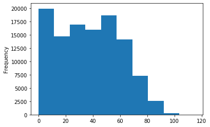

```python
# Bin the age groups into a new column
# Let's see good bins using histogram

import matplotlib.pyplot as plt
%matplotlib inline

df['age'].plot(kind='hist')

#help: https://towardsdatascience.com/sort-and-segment-your-data-into-bins-to-get-sorted-ranges-pandas-cut-and-qcut-7785931bbfde
```

```python
cut_age_group = ['0-20','20-40','40-60','60-80','>80']
cut_bins =[0, 20, 40, 60, 80, 115]
df['age_group'] = pd.cut(df['age'], bins=cut_bins, labels= cut_age_group, precision = 0)
```

```python
#Confirm that it worked

df.age_group.value_counts()
```

```
40-60    30081
20-40    28835
0-20     28309
60-80    16910
>80       2852
Name: age_group, dtype: int64
```

```python
#drop original age column - no longer needed

df.drop(['age'], axis=1, inplace=True)
```

```python
#Confirm that it worked
df.head()
```

|  | patientID | appointmentID | gender | scheduled_day | appointment_day | neighbourhood | scholarship | hypertension | diabetes | alcoholism | handicap | SMS_received | no_show | age_group |
| --- | --- | --- | --- | --- | --- | --- | --- | --- | --- | --- | --- | --- | --- | --- |
| 0 | 2.987250e+13 | 5642903 | F | 2016-04-29T18:38:08Z | 2016-04-29T00:00:00Z | JARDIM DA PENHA | False | True | False | False | 0 | False | False | 60-80 |
| 1 | 5.589978e+14 | 5642503 | M | 2016-04-29T16:08:27Z | 2016-04-29T00:00:00Z | JARDIM DA PENHA | False | False | False | False | 0 | False | False | 40-60 |
| 2 | 4.262962e+12 | 5642549 | F | 2016-04-29T16:19:04Z | 2016-04-29T00:00:00Z | MATA DA PRAIA | False | False | False | False | 0 | False | False | 60-80 |
| 3 | 8.679512e+11 | 5642828 | F | 2016-04-29T17:29:31Z | 2016-04-29T00:00:00Z | PONTAL DE CAMBURI | False | False | False | False | 0 | False | False | 0-20 |
| 4 | 8.841186e+12 | 5642494 | F | 2016-04-29T16:07:23Z | 2016-04-29T00:00:00Z | JARDIM DA PENHA | False | True | True | False | 0 | False | False | 40-60 |

```python
df.to_csv('noshowscleanedv1.csv', index=False)
```

```python
import pandas as pd
import numpy as np

df = pd.read_csv('noshowscleanedv1.csv')
```

```python
#Neighbourhood
df.neighbourhood.value_counts()

#81 unique values, all within one city, some with only one entry
```

```
JARDIM CAMBURI                 7717
MARIA ORTIZ                    5805
RESISTÊNCIA                    4431
JARDIM DA PENHA                3877
ITARARÉ                        3514
                               ...
ILHA DO BOI                      35
ILHA DO FRADE                    10
AEROPORTO                         8
ILHAS OCEÂNICAS DE TRINDADE       2
PARQUE INDUSTRIAL                 1
Name: neighbourhood, Length: 81, dtype: int64
```

```python
df.handicap.value_counts()

# Handcap means the number of handicaps the patient is suffering from
```

```
0    108285
1      2042
2       183
3        13
4         3
Name: handicap, dtype: int64
```

```python
df.patientID.value_counts()

# data type is float because they contain decimals
# 62298 unique values
```

```
8.221459e+14    88
9.963767e+10    84
2.688613e+13    70
3.353478e+13    65
7.579746e+13    62
                ..
3.997358e+11     1
1.338256e+11     1
1.192393e+13     1
3.224222e+11     1
2.724571e+11     1
Name: patientID, Length: 62298, dtype: int64
```

```python
# How much notice does the patient have of the appointment?

# Appointment day doesn't have relevant hours, but scheduled day does
# Some scheduled dates are the same as appointment dates, so hours are important
# Separate the date from the time for both columns
```

```python
df['appt_date'] = pd.to_datetime(df['appointment_day']).dt.date
df['appt_time'] = pd.to_datetime(df['appointment_day']).dt.time

#Help: https://stackoverflow.com/questions/35595710/splitting-timestamp-column-into-separate-date-and-time-columns
```

```python
df.head()
```

|  | patientID | appointmentID | gender | scheduled_day | appointment_day | neighbourhood | scholarship | hypertension | diabetes | alcoholism | handicap | SMS_received | no_show | age_group | appt_date | appt_time |
| --- | --- | --- | --- | --- | --- | --- | --- | --- | --- | --- | --- | --- | --- | --- | --- | --- |
| 0 | 2.987250e+13 | 5642903 | F | 2016-04-29T18:38:08Z | 2016-04-29T00:00:00Z | JARDIM DA PENHA | False | True | False | False | 0 | False | False | 60-80 | 2016-04-29 | 00:00:00 |
| 1 | 5.589978e+14 | 5642503 | M | 2016-04-29T16:08:27Z | 2016-04-29T00:00:00Z | JARDIM DA PENHA | False | False | False | False | 0 | False | False | 40-60 | 2016-04-29 | 00:00:00 |
| 2 | 4.262962e+12 | 5642549 | F | 2016-04-29T16:19:04Z | 2016-04-29T00:00:00Z | MATA DA PRAIA | False | False | False | False | 0 | False | False | 60-80 | 2016-04-29 | 00:00:00 |
| 3 | 8.679512e+11 | 5642828 | F | 2016-04-29T17:29:31Z | 2016-04-29T00:00:00Z | PONTAL DE CAMBURI | False | False | False | False | 0 | False | False | 0-20 | 2016-04-29 | 00:00:00 |
| 4 | 8.841186e+12 | 5642494 | F | 2016-04-29T16:07:23Z | 2016-04-29T00:00:00Z | JARDIM DA PENHA | False | True | True | False | 0 | False | False | 40-60 | 2016-04-29 | 00:00:00 |

```python
df['schd_date'] = pd.to_datetime(df['scheduled_day']).dt.date
df['schd_time'] = pd.to_datetime(df['scheduled_day']).dt.time
df.head()
```

|  | patientID | appointmentID | gender | scheduled_day | appointment_day | neighbourhood | scholarship | hypertension | diabetes | alcoholism | handicap | SMS_received | no_show | age_group | appt_date | appt_time | schd_date | schd_time |
| --- | --- | --- | --- | --- | --- | --- | --- | --- | --- | --- | --- | --- | --- | --- | --- | --- | --- | --- |
| 0 | 2.987250e+13 | 5642903 | F | 2016-04-29T18:38:08Z | 2016-04-29T00:00:00Z | JARDIM DA PENHA | False | True | False | False | 0 | False | False | 60-80 | 2016-04-29 | 00:00:00 | 2016-04-29 | 18:38:08 |
| 1 | 5.589978e+14 | 5642503 | M | 2016-04-29T16:08:27Z | 2016-04-29T00:00:00Z | JARDIM DA PENHA | False | False | False | False | 0 | False | False | 40-60 | 2016-04-29 | 00:00:00 | 2016-04-29 | 16:08:27 |
| 2 | 4.262962e+12 | 5642549 | F | 2016-04-29T16:19:04Z | 2016-04-29T00:00:00Z | MATA DA PRAIA | False | False | False | False | 0 | False | False | 60-80 | 2016-04-29 | 00:00:00 | 2016-04-29 | 16:19:04 |
| 3 | 8.679512e+11 | 5642828 | F | 2016-04-29T17:29:31Z | 2016-04-29T00:00:00Z | PONTAL DE CAMBURI | False | False | False | False | 0 | False | False | 0-20 | 2016-04-29 | 00:00:00 | 2016-04-29 | 17:29:31 |
| 4 | 8.841186e+12 | 5642494 | F | 2016-04-29T16:07:23Z | 2016-04-29T00:00:00Z | JARDIM DA PENHA | False | True | True | False | 0 | False | False | 40-60 | 2016-04-29 | 00:00:00 | 2016-04-29 | 16:07:23 |

```python
#Make appt_date and schd_date datetime type

df['appt_date'] = pd.to_datetime(df['appt_date'])
df['schd_date'] = pd.to_datetime(df['schd_date'])
df.dtypes
```

```
patientID                 float64
appointmentID               int64
gender                     object
scheduled_day              object
appointment_day            object
neighbourhood              object
scholarship                  bool
hypertension                 bool
diabetes                     bool
alcoholism                   bool
handicap                    int64
SMS_received                 bool
no_show                      bool
age_group                  object
appt_date          datetime64[ns]
appt_time                  object
schd_date          datetime64[ns]
schd_time                  object
dtype: object
```

```python
#Hours seems irrelevant now because anything more than 36 hours will be confusing
#Difference in days should be sufficient
#Subtract appt_date from schd_date in new column

df['diff_days'] = [int(i.days) for i in (df.appt_date - df.schd_date)]
df.head()
```

|  | patientID | appointmentID | gender | scheduled_day | appointment_day | neighbourhood | scholarship | hypertension | diabetes | alcoholism | handicap | SMS_received | no_show | age_group | appt_date | appt_time | schd_date | schd_time | diff_days |
| --- | --- | --- | --- | --- | --- | --- | --- | --- | --- | --- | --- | --- | --- | --- | --- | --- | --- | --- | --- |
| 0 | 2.987250e+13 | 5642903 | F | 2016-04-29T18:38:08Z | 2016-04-29T00:00:00Z | JARDIM DA PENHA | False | True | False | False | 0 | False | False | 60-80 | 2016-04-29 | 00:00:00 | 2016-04-29 | 18:38:08 | 0 |
| 1 | 5.589978e+14 | 5642503 | M | 2016-04-29T16:08:27Z | 2016-04-29T00:00:00Z | JARDIM DA PENHA | False | False | False | False | 0 | False | False | 40-60 | 2016-04-29 | 00:00:00 | 2016-04-29 | 16:08:27 | 0 |
| 2 | 4.262962e+12 | 5642549 | F | 2016-04-29T16:19:04Z | 2016-04-29T00:00:00Z | MATA DA PRAIA | False | False | False | False | 0 | False | False | 60-80 | 2016-04-29 | 00:00:00 | 2016-04-29 | 16:19:04 | 0 |
| 3 | 8.679512e+11 | 5642828 | F | 2016-04-29T17:29:31Z | 2016-04-29T00:00:00Z | PONTAL DE CAMBURI | False | False | False | False | 0 | False | False | 0-20 | 2016-04-29 | 00:00:00 | 2016-04-29 | 17:29:31 | 0 |
| 4 | 8.841186e+12 | 5642494 | F | 2016-04-29T16:07:23Z | 2016-04-29T00:00:00Z | JARDIM DA PENHA | False | True | True | False | 0 | False | False | 40-60 | 2016-04-29 | 00:00:00 | 2016-04-29 | 16:07:23 | 0 |

```python
df.diff_days.value_counts()

#-6 is an entry, which means there are entries less than 0 days, which probably means error
#Delete those entries
```

```
 0      38562
 2       6725
 4       5290
 1       5213
 7       4906
        ...
 117        1
 146        1
 82         1
-6          1
 127        1
Name: diff_days, Length: 131, dtype: int64
```

```python
df.nsmallest(7,'diff_days')

#There are 5 entries with -
#indicies = 71533,27033,55226,64175,72362
```

|  | patientID | appointmentID | gender | scheduled_day | appointment_day | neighbourhood | scholarship | hypertension | diabetes | alcoholism | handicap | SMS_received | no_show | age_group | appt_date | appt_time | schd_date | schd_time | diff_days |
| --- | --- | --- | --- | --- | --- | --- | --- | --- | --- | --- | --- | --- | --- | --- | --- | --- | --- | --- | --- |
| 71533 | 9.982316e+14 | 5686628 | F | 2016-05-11T13:49:20Z | 2016-05-05T00:00:00Z | SANTO ANTÔNIO | False | False | False | False | 0 | False | True | >80 | 2016-05-05 | 00:00:00 | 2016-05-11 | 13:49:20 | -6 |
| 27033 | 7.839273e+12 | 5679978 | M | 2016-05-10T10:51:53Z | 2016-05-09T00:00:00Z | RESISTÊNCIA | False | False | False | False | 1 | False | True | 20-40 | 2016-05-09 | 00:00:00 | 2016-05-10 | 10:51:53 | -1 |
| 55226 | 7.896294e+12 | 5715660 | F | 2016-05-18T14:50:41Z | 2016-05-17T00:00:00Z | SANTO ANTÔNIO | False | False | False | False | 1 | False | True | 0-20 | 2016-05-17 | 00:00:00 | 2016-05-18 | 14:50:41 | -1 |
| 64175 | 2.425226e+13 | 5664962 | F | 2016-05-05T13:43:58Z | 2016-05-04T00:00:00Z | CONSOLAÇÃO | False | False | False | False | 0 | False | True | 20-40 | 2016-05-04 | 00:00:00 | 2016-05-05 | 13:43:58 | -1 |
| 72362 | 3.787482e+12 | 5655637 | M | 2016-05-04T06:50:57Z | 2016-05-03T00:00:00Z | TABUAZEIRO | False | False | False | False | 0 | False | True | 0-20 | 2016-05-03 | 00:00:00 | 2016-05-04 | 06:50:57 | -1 |
| 0 | 2.987250e+13 | 5642903 | F | 2016-04-29T18:38:08Z | 2016-04-29T00:00:00Z | JARDIM DA PENHA | False | True | False | False | 0 | False | False | 60-80 | 2016-04-29 | 00:00:00 | 2016-04-29 | 18:38:08 | 0 |
| 1 | 5.589978e+14 | 5642503 | M | 2016-04-29T16:08:27Z | 2016-04-29T00:00:00Z | JARDIM DA PENHA | False | False | False | False | 0 | False | False | 40-60 | 2016-04-29 | 00:00:00 | 2016-04-29 | 16:08:27 | 0 |

```python
#Delete those 5 entries
df.drop([71533], inplace=True)
df.drop([27033], inplace=True)
df.drop([55226], inplace=True)
df.drop([64175], inplace=True)
df.drop([72362], inplace=True)
```

```python
#Confirm that drop worked

df.nsmallest(7,'diff_days')
```

|  | patientID | appointmentID | gender | scheduled_day | appointment_day | neighbourhood | scholarship | hypertension | diabetes | alcoholism | handicap | SMS_received | no_show | age_group | appt_date | appt_time | schd_date | schd_time | diff_days |
| --- | --- | --- | --- | --- | --- | --- | --- | --- | --- | --- | --- | --- | --- | --- | --- | --- | --- | --- | --- |
| 0 | 2.987250e+13 | 5642903 | F | 2016-04-29T18:38:08Z | 2016-04-29T00:00:00Z | JARDIM DA PENHA | False | True | False | False | 0 | False | False | 60-80 | 2016-04-29 | 00:00:00 | 2016-04-29 | 18:38:08 | 0 |
| 1 | 5.589978e+14 | 5642503 | M | 2016-04-29T16:08:27Z | 2016-04-29T00:00:00Z | JARDIM DA PENHA | False | False | False | False | 0 | False | False | 40-60 | 2016-04-29 | 00:00:00 | 2016-04-29 | 16:08:27 | 0 |
| 2 | 4.262962e+12 | 5642549 | F | 2016-04-29T16:19:04Z | 2016-04-29T00:00:00Z | MATA DA PRAIA | False | False | False | False | 0 | False | False | 60-80 | 2016-04-29 | 00:00:00 | 2016-04-29 | 16:19:04 | 0 |
| 3 | 8.679512e+11 | 5642828 | F | 2016-04-29T17:29:31Z | 2016-04-29T00:00:00Z | PONTAL DE CAMBURI | False | False | False | False | 0 | False | False | 0-20 | 2016-04-29 | 00:00:00 | 2016-04-29 | 17:29:31 | 0 |
| 4 | 8.841186e+12 | 5642494 | F | 2016-04-29T16:07:23Z | 2016-04-29T00:00:00Z | JARDIM DA PENHA | False | True | True | False | 0 | False | False | 40-60 | 2016-04-29 | 00:00:00 | 2016-04-29 | 16:07:23 | 0 |
| 8 | 5.639473e+13 | 5638447 | F | 2016-04-29T08:02:16Z | 2016-04-29T00:00:00Z | ANDORINHAS | False | False | False | False | 0 | False | False | 20-40 | 2016-04-29 | 00:00:00 | 2016-04-29 | 08:02:16 | 0 |
| 19 | 7.223289e+12 | 5640433 | F | 2016-04-29T10:43:14Z | 2016-04-29T00:00:00Z | DA PENHA | False | False | False | False | 0 | False | False | 40-60 | 2016-04-29 | 00:00:00 | 2016-04-29 | 10:43:14 | 0 |

```python
df.to_csv('noshowscleanedv3.csv', index=False)
```

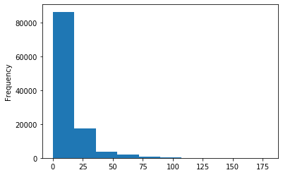

```python
#See the spread of diff_days

import matplotlib.pyplot as plt
%matplotlib inline

df['diff_days'].plot(kind='hist')
```

```python
#Bucket these to same day, 1-2 days, 3-4 days, 5-10 days, 10-30 days, 30+ days

df.nlargest(3,'diff_days')
```

|  | patientID | appointmentID | gender | scheduled_day | appointment_day | neighbourhood | scholarship | hypertension | diabetes | alcoholism | handicap | SMS_received | no_show | age_group | appt_date | appt_time | schd_date | schd_time | diff_days |
| --- | --- | --- | --- | --- | --- | --- | --- | --- | --- | --- | --- | --- | --- | --- | --- | --- | --- | --- | --- |
| 102785 | 4.542871e+11 | 5134227 | M | 2015-12-07T10:43:34Z | 2016-06-03T00:00:00Z | MARUÍPE | False | True | True | False | 0 | False | False | 60-80 | 2016-06-03 | 00:00:00 | 2015-12-07 | 10:43:34 | 179 |
| 102787 | 2.547555e+14 | 5134249 | F | 2015-12-07T10:45:01Z | 2016-06-03T00:00:00Z | SÃO CRISTÓVÃO | False | True | True | False | 0 | True | False | 60-80 | 2016-06-03 | 00:00:00 | 2015-12-07 | 10:45:01 | 179 |
| 102788 | 3.112342e+13 | 5134239 | F | 2015-12-07T10:44:25Z | 2016-06-03T00:00:00Z | SÃO CRISTÓVÃO | False | True | True | False | 0 | True | False | 40-60 | 2016-06-03 | 00:00:00 | 2015-12-07 | 10:44:25 | 179 |

```python
cut_diff_days_group = ['0','1-2','3-4','5-10','11-30','>30']
cut_bins =[-1, 0, 2, 4, 10, 30, 179]
df['diff_days_group'] = pd.cut(df['diff_days'], bins=cut_bins, labels= cut_diff_days_group, precision = 0)
```

```python
#Confirm that it worked

df.diff_days_group.value_counts()
```

```
0        38562
11-30    24068
5-10     17548
1-2      11938
>30      10378
3-4       8027
Name: diff_days_group, dtype: int64
```

```python
df.head(25)
```

|  | patientID | appointmentID | gender | scheduled_day | appointment_day | neighbourhood | scholarship | hypertension | diabetes | alcoholism | handicap | SMS_received | no_show | age_group | appt_date | appt_time | schd_date | schd_time | diff_days | diff_days_group |
| --- | --- | --- | --- | --- | --- | --- | --- | --- | --- | --- | --- | --- | --- | --- | --- | --- | --- | --- | --- | --- |
| 0 | 2.987250e+13 | 5642903 | F | 2016-04-29T18:38:08Z | 2016-04-29T00:00:00Z | JARDIM DA PENHA | False | True | False | False | 0 | False | False | 60-80 | 2016-04-29 | 00:00:00 | 2016-04-29 | 18:38:08 | 0 | 0 |
| 1 | 5.589978e+14 | 5642503 | M | 2016-04-29T16:08:27Z | 2016-04-29T00:00:00Z | JARDIM DA PENHA | False | False | False | False | 0 | False | False | 40-60 | 2016-04-29 | 00:00:00 | 2016-04-29 | 16:08:27 | 0 | 0 |
| 2 | 4.262962e+12 | 5642549 | F | 2016-04-29T16:19:04Z | 2016-04-29T00:00:00Z | MATA DA PRAIA | False | False | False | False | 0 | False | False | 60-80 | 2016-04-29 | 00:00:00 | 2016-04-29 | 16:19:04 | 0 | 0 |
| 3 | 8.679512e+11 | 5642828 | F | 2016-04-29T17:29:31Z | 2016-04-29T00:00:00Z | PONTAL DE CAMBURI | False | False | False | False | 0 | False | False | 0-20 | 2016-04-29 | 00:00:00 | 2016-04-29 | 17:29:31 | 0 | 0 |
| 4 | 8.841186e+12 | 5642494 | F | 2016-04-29T16:07:23Z | 2016-04-29T00:00:00Z | JARDIM DA PENHA | False | True | True | False | 0 | False | False | 40-60 | 2016-04-29 | 00:00:00 | 2016-04-29 | 16:07:23 | 0 | 0 |
| 5 | 9.598513e+13 | 5626772 | F | 2016-04-27T08:36:51Z | 2016-04-29T00:00:00Z | REPÚBLICA | False | True | False | False | 0 | False | False | 60-80 | 2016-04-29 | 00:00:00 | 2016-04-27 | 08:36:51 | 2 | 1-2 |
| 6 | 7.336882e+14 | 5630279 | F | 2016-04-27T15:05:12Z | 2016-04-29T00:00:00Z | GOIABEIRAS | False | False | False | False | 0 | False | True | 20-40 | 2016-04-29 | 00:00:00 | 2016-04-27 | 15:05:12 | 2 | 1-2 |
| 7 | 3.449833e+12 | 5630575 | F | 2016-04-27T15:39:58Z | 2016-04-29T00:00:00Z | GOIABEIRAS | False | False | False | False | 0 | False | True | 20-40 | 2016-04-29 | 00:00:00 | 2016-04-27 | 15:39:58 | 2 | 1-2 |
| 8 | 5.639473e+13 | 5638447 | F | 2016-04-29T08:02:16Z | 2016-04-29T00:00:00Z | ANDORINHAS | False | False | False | False | 0 | False | False | 20-40 | 2016-04-29 | 00:00:00 | 2016-04-29 | 08:02:16 | 0 | 0 |
| 9 | 7.812456e+13 | 5629123 | F | 2016-04-27T12:48:25Z | 2016-04-29T00:00:00Z | CONQUISTA | False | False | False | False | 0 | False | False | 0-20 | 2016-04-29 | 00:00:00 | 2016-04-27 | 12:48:25 | 2 | 1-2 |
| 10 | 7.345362e+14 | 5630213 | F | 2016-04-27T14:58:11Z | 2016-04-29T00:00:00Z | NOVA PALESTINA | False | False | False | False | 0 | False | False | 20-40 | 2016-04-29 | 00:00:00 | 2016-04-27 | 14:58:11 | 2 | 1-2 |
| 11 | 7.542951e+12 | 5620163 | M | 2016-04-26T08:44:12Z | 2016-04-29T00:00:00Z | NOVA PALESTINA | False | False | False | False | 0 | True | True | 20-40 | 2016-04-29 | 00:00:00 | 2016-04-26 | 08:44:12 | 3 | 3-4 |
| 12 | 5.666548e+14 | 5634718 | F | 2016-04-28T11:33:51Z | 2016-04-29T00:00:00Z | NOVA PALESTINA | True | False | False | False | 0 | False | False | 20-40 | 2016-04-29 | 00:00:00 | 2016-04-28 | 11:33:51 | 1 | 1-2 |
| 13 | 9.113946e+14 | 5636249 | M | 2016-04-28T14:52:07Z | 2016-04-29T00:00:00Z | NOVA PALESTINA | False | False | False | False | 0 | False | False | 20-40 | 2016-04-29 | 00:00:00 | 2016-04-28 | 14:52:07 | 1 | 1-2 |
| 14 | 9.988472e+13 | 5633951 | F | 2016-04-28T10:06:24Z | 2016-04-29T00:00:00Z | NOVA PALESTINA | False | False | False | False | 0 | False | False | 40-60 | 2016-04-29 | 00:00:00 | 2016-04-28 | 10:06:24 | 1 | 1-2 |
| 15 | 9.994839e+10 | 5620206 | F | 2016-04-26T08:47:27Z | 2016-04-29T00:00:00Z | NOVA PALESTINA | False | False | False | False | 0 | True | False | 0-20 | 2016-04-29 | 00:00:00 | 2016-04-26 | 08:47:27 | 3 | 3-4 |
| 16 | 8.457439e+13 | 5633121 | M | 2016-04-28T08:51:47Z | 2016-04-29T00:00:00Z | NOVA PALESTINA | False | False | False | False | 0 | False | False | 40-60 | 2016-04-29 | 00:00:00 | 2016-04-28 | 08:51:47 | 1 | 1-2 |
| 17 | 1.479497e+13 | 5633460 | F | 2016-04-28T09:28:57Z | 2016-04-29T00:00:00Z | CONQUISTA | True | False | False | False | 0 | False | True | 20-40 | 2016-04-29 | 00:00:00 | 2016-04-28 | 09:28:57 | 1 | 1-2 |
| 18 | 1.713538e+13 | 5621836 | F | 2016-04-26T10:54:18Z | 2016-04-29T00:00:00Z | NOVA PALESTINA | True | False | False | False | 0 | True | False | 20-40 | 2016-04-29 | 00:00:00 | 2016-04-26 | 10:54:18 | 3 | 3-4 |
| 19 | 7.223289e+12 | 5640433 | F | 2016-04-29T10:43:14Z | 2016-04-29T00:00:00Z | DA PENHA | False | False | False | False | 0 | False | False | 40-60 | 2016-04-29 | 00:00:00 | 2016-04-29 | 10:43:14 | 0 | 0 |
| 20 | 6.222575e+14 | 5626083 | F | 2016-04-27T07:51:14Z | 2016-04-29T00:00:00Z | NOVA PALESTINA | False | False | False | False | 0 | False | True | 20-40 | 2016-04-29 | 00:00:00 | 2016-04-27 | 07:51:14 | 2 | 1-2 |
| 21 | 1.215484e+13 | 5628338 | F | 2016-04-27T10:50:45Z | 2016-04-29T00:00:00Z | CONQUISTA | False | False | False | False | 0 | False | True | 0-20 | 2016-04-29 | 00:00:00 | 2016-04-27 | 10:50:45 | 2 | 1-2 |
| 22 | 8.632298e+14 | 5616091 | M | 2016-04-25T13:29:16Z | 2016-04-29T00:00:00Z | CONQUISTA | False | False | False | False | 0 | True | True | 0-20 | 2016-04-29 | 00:00:00 | 2016-04-25 | 13:29:16 | 4 | 3-4 |
| 23 | 2.137540e+14 | 5634142 | F | 2016-04-28T10:27:05Z | 2016-04-29T00:00:00Z | CONQUISTA | False | False | False | False | 0 | False | False | 40-60 | 2016-04-29 | 00:00:00 | 2016-04-28 | 10:27:05 | 1 | 1-2 |
| 24 | 8.734858e+12 | 5641780 | F | 2016-04-29T14:19:19Z | 2016-04-29T00:00:00Z | TABUAZEIRO | False | False | False | False | 0 | False | False | 60-80 | 2016-04-29 | 00:00:00 | 2016-04-29 | 14:19:19 | 0 | 0 |

```python
df.to_csv('noshowscleanedv3.csv', index=False)
```